# Lakshman Kumar S - Project - Unsupervised Learning - Total Marks 60

# Part A - 30 Marks

• **DOMAIN:** Automobile

• **CONTEXT:** The data concerns city-cycle fuel consumption in miles per gallon to be predicted in terms of 3 multivalued discrete and 5 continuous attributes.

• **DATA DESCRIPTION:**

**cylinders:** multi-valued discrete

**acceleration:** continuous

**displacement:** continuous

**model year:** multi-valued discrete

**horsepower:** continuous

**origin:** multi-valued discrete

**weight:** continuous car

**name:** string (unique for each instance)

**mpg:** continuous

• **PROJECT OBJECTIVE:** To understand K-means Clustering by applying on the Car Dataset to segment the cars into various categories.

### • STEPS AND TASK [30 Marks]:

### 1. Data Understanding & Exploration: [5 Marks]

```python
# Basic packages
import pandas as pd, numpy as np, matplotlib.pyplot as plt, seaborn as sns
from scipy import stats; from scipy.stats import zscore, norm, randint
import matplotlib.style as style; style.use('fivethirtyeight')
import plotly.express as px
%matplotlib inline


# Modelling - LR, KNN, NB, Metrics
from sklearn.preprocessing import LabelEncoder
from sklearn.model_selection import train_test_split
from sklearn.metrics import precision_recall_fscore_support, mean_absolute_error
from sklearn.metrics import accuracy_score, confusion_matrix, classification_report
from sklearn.preprocessing import StandardScaler
from sklearn.metrics import classification_report, confusion_matrix, accuracy_score, f1_score, recall_score, precision_score, roc_auc_score, roc_curve, r2_score, mean_squared_error, mean_squared_log_error, make_scorer
from sklearn.metrics import make_scorer
from sklearn.svm import SVC
from sklearn.cluster import KMeans

# methods and classes for evaluation
from sklearn import metrics
from math import sqrt
from sklearn.model_selection import cross_validate
import time

# Suppress warnings
import warnings; warnings.filterwarnings('ignore')

# Display settings
pd.options.display.max_rows = 10000
pd.options.display.max_columns = 10000

random_state = 42
np.random.seed(random_state)
```

#### A. Read ‘Car name.csv’ as a DataFrame and assign it to a variable. [1 Mark]

```python
# Read data and check for first 5 rows
car_name = pd.read_csv('Car name.csv')
car_name.head(5)
```

|  | car_name |
| --- | --- |
| 0 | chevrolet chevelle malibu |
| 1 | buick skylark 320 |
| 2 | plymouth satellite |
| 3 | amc rebel sst |
| 4 | ford torino |

```python
row, column = car_name.shape
print('The dataset contains', row, 'rows and', column, 'columns')
```

```
The dataset contains 398 rows and 1 columns
```

#### B. Read ‘Car-Attributes.json as a DataFrame and assign it to a variable. [1 Mark]

```python
# Read data and check for first 5 rows
car_attr = pd.read_json('Car-Attributes.json')
car_attr.head(5)
```

|  | mpg | cyl | disp | hp | wt | acc | yr | origin |
| --- | --- | --- | --- | --- | --- | --- | --- | --- |
| 0 | 18.0 | 8 | 307.0 | 130 | 3504 | 12.0 | 70 | 1 |
| 1 | 15.0 | 8 | 350.0 | 165 | 3693 | 11.5 | 70 | 1 |
| 2 | 18.0 | 8 | 318.0 | 150 | 3436 | 11.0 | 70 | 1 |
| 3 | 16.0 | 8 | 304.0 | 150 | 3433 | 12.0 | 70 | 1 |
| 4 | 17.0 | 8 | 302.0 | 140 | 3449 | 10.5 | 70 | 1 |

```python
row, column = car_attr.shape
print('The dataset contains', row, 'rows and', column, 'columns')
```

```
The dataset contains 398 rows and 8 columns
```

#### C. Merge both the DataFrames together to form a single DataFrame [2 Mark]

```python
car_details = pd.concat([car_name, car_attr], axis = 1)
car_details.head()
```

|  | car_name | mpg | cyl | disp | hp | wt | acc | yr | origin |
| --- | --- | --- | --- | --- | --- | --- | --- | --- | --- |
| 0 | chevrolet chevelle malibu | 18.0 | 8 | 307.0 | 130 | 3504 | 12.0 | 70 | 1 |
| 1 | buick skylark 320 | 15.0 | 8 | 350.0 | 165 | 3693 | 11.5 | 70 | 1 |
| 2 | plymouth satellite | 18.0 | 8 | 318.0 | 150 | 3436 | 11.0 | 70 | 1 |
| 3 | amc rebel sst | 16.0 | 8 | 304.0 | 150 | 3433 | 12.0 | 70 | 1 |
| 4 | ford torino | 17.0 | 8 | 302.0 | 140 | 3449 | 10.5 | 70 | 1 |

```python
car_name_col = car_name.columns
car_attr_col = car_attr.columns
car_details_append = set(np.append(car_name_col,car_attr_col))
car_details_col = set(car_details.columns)
```

```python
if (car_details_col == car_details_append):
    print('All columns are incorporated in merged DataFrame')
else:
    print('All columns are not incorporated in merged DataFrame')
```

```
All columns are incorporated in merged DataFrame
```

```python
row, column = car_details.shape
print('The dataset contains', row, 'rows and', column, 'columns')
```

```
The dataset contains 398 rows and 9 columns
```

#### D. Print 5 point summary of the numerical features and share insights. [1 Marks]

```python
car_details.describe().T
```

|  | count | mean | std | min | 25% | 50% | 75% | max |
| --- | --- | --- | --- | --- | --- | --- | --- | --- |
| mpg | 398.0 | 23.514573 | 7.815984 | 9.0 | 17.500 | 23.0 | 29.000 | 46.6 |
| cyl | 398.0 | 5.454774 | 1.701004 | 3.0 | 4.000 | 4.0 | 8.000 | 8.0 |
| disp | 398.0 | 193.425879 | 104.269838 | 68.0 | 104.250 | 148.5 | 262.000 | 455.0 |
| wt | 398.0 | 2970.424623 | 846.841774 | 1613.0 | 2223.750 | 2803.5 | 3608.000 | 5140.0 |
| acc | 398.0 | 15.568090 | 2.757689 | 8.0 | 13.825 | 15.5 | 17.175 | 24.8 |
| yr | 398.0 | 76.010050 | 3.697627 | 70.0 | 73.000 | 76.0 | 79.000 | 82.0 |
| origin | 398.0 | 1.572864 | 0.802055 | 1.0 | 1.000 | 1.0 | 2.000 | 3.0 |

From the above results, we could observe that

All attributes are having different ranges and units. Here, **Standardization is required.**

mpg - median is approximately halfway between Q1 and Q3, so it is symmetrical.

cyl - median is equal to Q1, so it is right-skewed.

disp - median is closer to Q1, so it is right-skewed.

yr - median is approximately halfway between Q1 and Q3, so it is symmetrical.

orgin - median is closer to Q1, so it is right-skewed.

### 2. Data Preparation & Analysis: [10 Marks]

#### A. Check and print feature-wise percentage of missing values present in the data and impute with the best suitable approach. [2 Mark]

```python
car_details.isnull().sum()* 100 / len(car_details)
```

```
car_name    0.0
mpg         0.0
cyl         0.0
disp        0.0
hp          0.0
wt          0.0
acc         0.0
yr          0.0
origin      0.0
dtype: float64
```

Thus, from above results we could see that there are no missing values present in the given dataset. Missing values Imputation is not required in this case.

#### B. Check for duplicate values in the data and impute with the best suitable approach. [1 Mark]

```python
car_details.duplicated().value_counts()
```

```
False    398
dtype: int64
```

Thus no True value, which implies there are no duplicates in dataframe. Duplicate values Imputation is not required in this case.

#### C. Plot a pairplot for all features. [1 Marks]

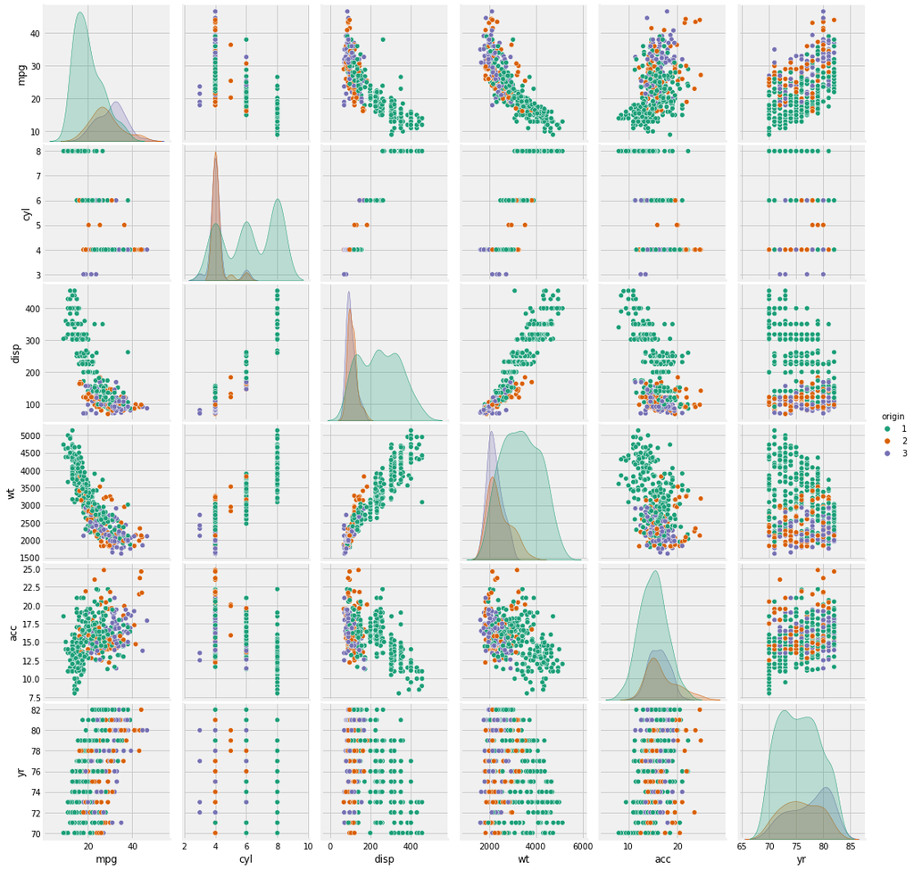

```python
car_details_attr=car_details.iloc[:,1:]
sns.pairplot(car_details_attr,diag_kind='kde',palette="Dark2",hue="origin")
```

#### D. Visualize a scatterplot for ‘wt’ and ‘disp’. Datapoints should be distinguishable by ‘cyl’. [1 Marks]

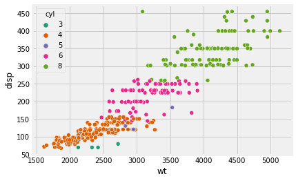

```python
sns.scatterplot(x=car_details['wt'],y=car_details['disp'],hue = car_details['cyl'], palette="Dark2");
```

#### E. Share insights for Q2.d. [1 Marks]

From the above scatterplot we could observe that

1. Based on the relationship between 'wt' and 'disp', we can conclude that there is a positive correlation
2. Based on the colour hue we have for 'cyl', we can conclude that for the third categorical variable 'cyl' with values 4, 6, 8 there is almost a clear distinguishion between the 'wt' and 'disp'. And, for 'cyl' values 3, 5 there is no clear distinguishion between the 'wt' and 'disp' as there are very less points and they are overlapped with other values.

#### F. Visualize a scatterplot for ‘wt’ and ’mpg’. Datapoints should be distinguishable by ‘cyl’. [1 Marks]

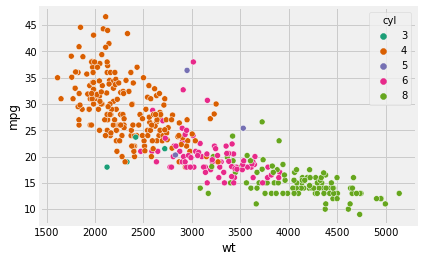

```python
sns.scatterplot(x=car_details['wt'],y=car_details['mpg'],hue = car_details['cyl'], palette="Dark2");
```

#### G. Share insights for Q2.f. [1 Marks]

From the above scatterplot we could observe that

1. Based on the relationship between 'wt' and 'mpg', we can conclude that there is a negative correlation
2. Based on the colour hue we have for 'cyl', we can conclude that for the third categorical variable 'cyl' with values 4, 6, 8 there is almost a clear distinguishion between the 'wt' and 'mpg'. And, for 'cyl' values 3, 5 there is no clear distinguishion between the 'wt' and 'mpg' as there are very less points and they are overlapped with other values.

#### H. Check for unexpected values in all the features and datapoints with such values. [2 Marks]

#### [Hint: ‘?’ is present in ‘hp’]

```python
car_details['hp'].value_counts()
```

```
150    22
90     20
88     19
110    18
100    17
75     14
95     14
105    12
67     12
70     12
65     10
85      9
97      9
145     7
80      7
```

[output cut: 80 more lines]

```python
# Finding number of records with value '?'
car_details[['hp']].eq('?').sum()
```

```
hp    6
dtype: int64
```

There are 6 records with '?' as value

```python
# convert the records having '?' to nulls
car_details.replace('?',np.nan,inplace=True)
```

```python
# Drop the records containing null
car_details.dropna(inplace=True)
```

```python
row, column = car_details.shape
print('The dataset contains', row, 'rows and', column, 'columns')
```

```
The dataset contains 392 rows and 9 columns
```

```python
car_details = car_details.astype({'hp':'int64'})
```

```python
car_details.dtypes
```

```
car_name     object
mpg         float64
cyl           int64
disp        float64
hp            int64
wt            int64
acc         float64
yr            int64
origin        int64
dtype: object
```

### 3. Clustering: [15 Marks]

#### A. Apply K-Means clustering for 2 to 10 clusters. [3 Marks]

```python
car_details_attr=car_details.iloc[:,1:]
car_details_scaled=car_details_attr.apply(zscore)
```

```python
#Finding optimal no. of clusters
from scipy.spatial.distance import cdist
clusters=range(2,11)
meanDistortions=[]

for k in clusters:
    model=KMeans(n_clusters=k)
    model.fit(car_details_scaled)
    prediction=model.predict(car_details_scaled)
    meanDistortions.append(sum(np.min(cdist(car_details_scaled, model.cluster_centers_, 'euclidean'), axis=1)) / car_details_scaled.shape[0])
```

```python
print(f'Sum of Squared Distances:', meanDistortions)
```

```
Sum of Squared Distances: [1.9091840803351565, 1.628758749472895, 1.4759079656341865, 1.3336142756495504, 1.2785479685513883, 1.2135253939196822, 1.1672568622731838, 1.1411730852107678, 1.106138628215925]
```

#### Calculating WSS for other values of K - Elbow Method

```python
wss = []

for i in range(1,11):
    KM = KMeans(n_clusters=i)
    KM.fit(car_details_scaled)
    wss.append(KM.inertia_)
```

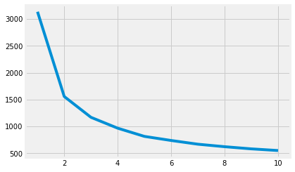

```python
plt.plot(range(1,11), wss)
```

Thus, WSS reduces as K keeps increasing

#### B. Plot a visual and find elbow point. [2 Marks]

```
Optimal Elbow point is: 5
```

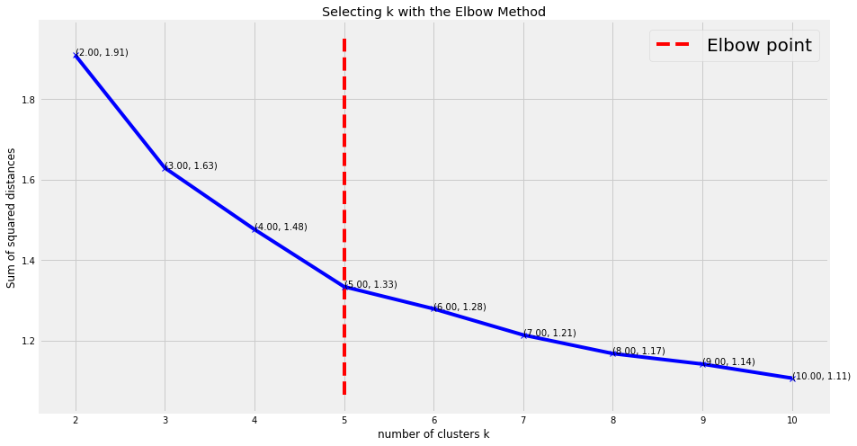

```python
y = meanDistortions

x = range(2, len(y)+2)

from kneed import KneeLocator

kn = KneeLocator(x, y, curve='convex', direction='decreasing')
print('Optimal Elbow point is:', kn.knee)

plt.rcParams["figure.figsize"] = (14,8)

for xy in zip(clusters, meanDistortions):
    plt.annotate('(%.2f, %.2f)' % xy, xy=xy)

plt.xlabel('number of clusters k')
plt.ylabel('Sum of squared distances')
plt.title('Selecting k with the Elbow Method')
plt.plot(x, y, 'bx-')
plt.vlines(kn.knee, plt.ylim()[0], plt.ylim()[1], linestyles='dashed', color = 'r', label = 'Elbow point')
plt.legend(fontsize=20); plt.show()
```

The Elbow points are 5 (with a difference of 0.05) and 8 (with a difference of 0.03) clusters, as there is a clear bend and difference.

#### C. On the above visual, highlight which are the possible Elbow points. [1 Marks]

Highlighting the Elbow points 5 (with a difference of 0.05) and 8 (with a difference of 0.03) clusters.

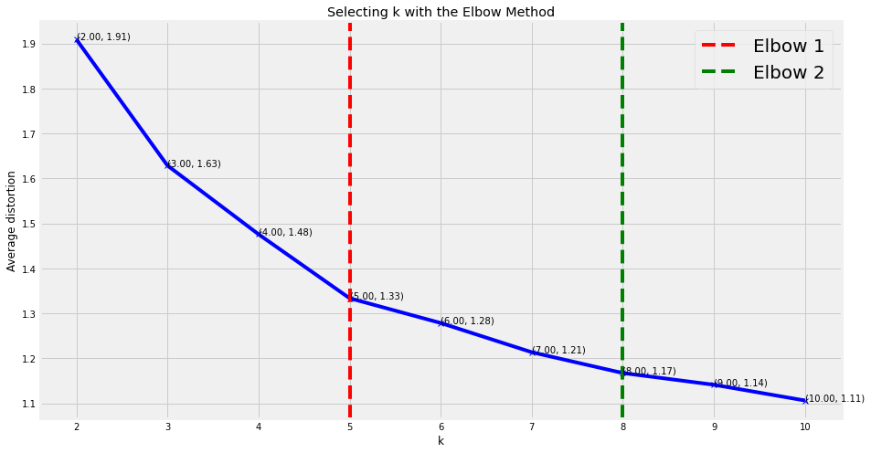

```python
elb1 = 5
elb2 = 8
plt.plot(clusters, meanDistortions, 'bx-')
plt.xlabel('k')
plt.ylabel('Average distortion')
plt.title('Selecting k with the Elbow Method')
for xy in zip(clusters, meanDistortions):
    plt.annotate('(%.2f, %.2f)' % xy, xy=xy)
plt.rcParams["figure.figsize"] = (14,8)
plt.axvline(elb1, color = 'r', linestyle = '--', label = 'Elbow 1')
plt.axvline(elb2, color = 'g', linestyle = '--', label = 'Elbow 2')
plt.legend(fontsize=20); plt.show()
```

#### D. Train a K-means clustering model once again on the optimal number of clusters. [3 Marks]

```python
# Optimal Elbow Point K = 5
final_model=KMeans(n_clusters=5, n_init = 15, random_state=2345)
final_model_mod = final_model.fit(car_details_attr)
prediction=final_model_mod.predict(car_details_attr)
```

```python
centroids = final_model_mod.cluster_centers_
```

```python
centroids
```

```
array([[1.97046154e+01, 6.26153846e+00, 2.39461538e+02, 1.06292308e+02,
        3.30055385e+03, 1.62384615e+01, 7.59692308e+01, 1.13846154e+00],
       [1.35510638e+01, 8.00000000e+00, 3.69914894e+02, 1.74595745e+02,
        4.50451064e+03, 1.27872340e+01, 7.30425532e+01, 1.00000000e+00],
       [3.09893939e+01, 3.98484848e+00, 9.75492424e+01, 7.24393939e+01,
        2.09853788e+03, 1.66053030e+01, 7.66666667e+01, 2.18181818e+00],
       [2.46478723e+01, 4.55319149e+00, 1.47042553e+02, 9.44468085e+01,
        2.70625532e+03, 1.56521277e+01, 7.70531915e+01, 1.63829787e+00],
       [1.60296296e+01, 7.55555556e+00, 3.06666667e+02, 1.36981481e+02,
        3.88092593e+03, 1.43055556e+01, 7.50000000e+01, 1.01851852e+00]])
```

```python
#Clculate the centroids for the columns to profile
centroid_df = pd.DataFrame(centroids, columns = list(car_details_attr))
```

```python
print(centroid_df)
```

```
         mpg       cyl        disp          hp           wt        acc  \
0  19.704615  6.261538  239.461538  106.292308  3300.553846  16.238462
1  13.551064  8.000000  369.914894  174.595745  4504.510638  12.787234
2  30.989394  3.984848   97.549242   72.439394  2098.537879  16.605303
3  24.647872  4.553191  147.042553   94.446809  2706.255319  15.652128
4  16.029630  7.555556  306.666667  136.981481  3880.925926  14.305556

          yr    origin
0  75.969231  1.138462
1  73.042553  1.000000
2  76.666667  2.181818
3  77.053191  1.638298
4  75.000000  1.018519
```

#### Within clusters sum of squares

```python
final_model_mod.inertia_
```

```
13487942.021211946
```

#### Forming clusters with K = 3,4,5,6,7,8 and comparing the WSS

```python
k_means = KMeans(n_clusters = 3)
k_means.fit(car_details_attr)
print('WSS when K = 3 is:', k_means.inertia_)

k_means = KMeans(n_clusters = 4)
k_means.fit(car_details_attr)
print('WSS when K = 4 is:', k_means.inertia_)

k_means = KMeans(n_clusters = 5)
k_means.fit(car_details_attr)
print('WSS when K = 5 is:', k_means.inertia_)

k_means = KMeans(n_clusters = 6)
k_means.fit(car_details_attr)
print('WSS when K = 6 is:', k_means.inertia_)

k_means = KMeans(n_clusters = 7)
k_means.fit(car_details_attr)
print('WSS when K = 7 is:', k_means.inertia_)

k_means = KMeans(n_clusters = 8)
k_means.fit(car_details_attr)
print('WSS when K = 8 is:', k_means.inertia_)
```

```
WSS when K = 3 is: 33849200.97782877
WSS when K = 4 is: 18811096.498068184
WSS when K = 5 is: 13495628.292181777
WSS when K = 6 is: 10147657.526409065
WSS when K = 7 is: 7530197.427407158
WSS when K = 8 is: 5615321.562875867
```

Thus, WSS reduces as K keeps increasing

```python
from sklearn.metrics import silhouette_samples, silhouette_score

k_means = KMeans(n_clusters = 5)
k_means.fit(car_details_attr)
labels = k_means.labels_
print('silhouette_score when K = 5 is:', silhouette_score(car_details_attr,labels))

k_means = KMeans(n_clusters = 6)
k_means.fit(car_details_attr)
labels = k_means.labels_
print('silhouette_score when K = 6 is:', silhouette_score(car_details_attr,labels))

k_means = KMeans(n_clusters = 7)
k_means.fit(car_details_attr)
labels = k_means.labels_
print('silhouette_score when K = 7 is:', silhouette_score(car_details_attr,labels))

k_means = KMeans(n_clusters = 8)
k_means.fit(car_details_attr)
labels = k_means.labels_
print('silhouette_score when K = 8 is:', silhouette_score(car_details_attr,labels))
```

```
silhouette_score when K = 5 is: 0.5495726272297005
silhouette_score when K = 6 is: 0.5264159939280573
silhouette_score when K = 7 is: 0.5169061740090208
silhouette_score when K = 8 is: 0.5218300051599033
```

Silhouette score is better for 5 clusters than for 6, 7, 8 clusters. So, final clusters will be 5

#### E. Add a new feature in the DataFrame which will have labels based upon cluster value. [2 Marks]

```python
#Append the prediction as a new feature "GROUP" to car_details
car_details["GROUP"] = prediction
car_details_scaled["GROUP"] = prediction
print("Groups Assigned : \n")
car_details.sample(n=10)
```

```
Groups Assigned :
```

|  | car_name | mpg | cyl | disp | hp | wt | acc | yr | origin | GROUP |
| --- | --- | --- | --- | --- | --- | --- | --- | --- | --- | --- |
| 320 | datsun 510 hatchback | 37.0 | 4 | 119.0 | 92 | 2434 | 15.0 | 80 | 3 | 3 |
| 186 | renault 12tl | 27.0 | 4 | 101.0 | 83 | 2202 | 15.3 | 76 | 2 | 2 |
| 20 | peugeot 504 | 25.0 | 4 | 110.0 | 87 | 2672 | 17.5 | 70 | 2 | 3 |
| 60 | chevrolet vega | 20.0 | 4 | 140.0 | 90 | 2408 | 19.5 | 72 | 1 | 3 |
| 102 | volkswagen super beetle | 26.0 | 4 | 97.0 | 46 | 1950 | 21.0 | 73 | 2 | 2 |
| 208 | plymouth volare premier v8 | 13.0 | 8 | 318.0 | 150 | 3940 | 13.2 | 76 | 1 | 4 |
| 259 | mercury zephyr | 20.8 | 6 | 200.0 | 85 | 3070 | 16.7 | 78 | 1 | 0 |
| 21 | audi 100 ls | 24.0 | 4 | 107.0 | 90 | 2430 | 14.5 | 70 | 2 | 3 |
| 175 | volkswagen rabbit | 29.0 | 4 | 90.0 | 70 | 1937 | 14.0 | 75 | 2 | 2 |
| 232 | ford thunderbird | 16.0 | 8 | 351.0 | 149 | 4335 | 14.5 | 77 | 1 | 1 |

```python
car_details_clust = car_details.groupby(['GROUP'])
car_details_clust.mean()
```

| GROUP | mpg | cyl | disp | hp | wt | acc | yr | origin |
| --- | --- | --- | --- | --- | --- | --- | --- | --- |
| 0 | 19.704615 | 6.261538 | 239.461538 | 106.292308 | 3300.553846 | 16.238462 | 75.969231 | 1.138462 |
| 1 | 13.551064 | 8.000000 | 369.914894 | 174.595745 | 4504.510638 | 12.787234 | 73.042553 | 1.000000 |
| 2 | 30.989394 | 3.984848 | 97.549242 | 72.439394 | 2098.537879 | 16.605303 | 76.666667 | 2.181818 |
| 3 | 24.647872 | 4.553191 | 147.042553 | 94.446809 | 2706.255319 | 15.652128 | 77.053191 | 1.638298 |
| 4 | 16.029630 | 7.555556 | 306.666667 | 136.981481 | 3880.925926 | 14.305556 | 75.000000 | 1.018519 |

#### F. Plot a visual and color the datapoints based upon clusters. [2 Marks]

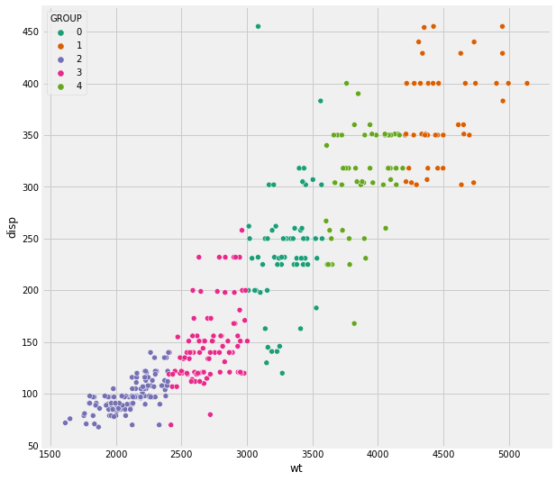

```python
# Scatter plot between 'wt' and 'disp', based on "GROUP"
plt.rcParams["figure.figsize"] = (9,9)
sns.scatterplot(x=car_details['wt'],y=car_details['disp'],hue = car_details['GROUP'], palette="Dark2");
```

Thus, now we are able to see a clear distinguish between the features, based on the group we derived from the optimal elbow point

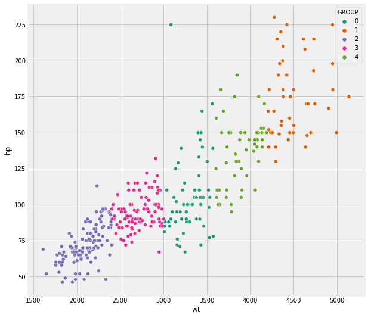

```python
# Scatter plot between 'wt' and 'hp', based on "GROUP"
plt.rcParams["figure.figsize"] = (9,9)
sns.scatterplot(x=car_details['wt'],y=car_details['hp'],hue = car_details['GROUP'], palette="Dark2");
```

Thus, now we are able to see a clear distinguish between the features, based on the group we derived from the optimal elbow point

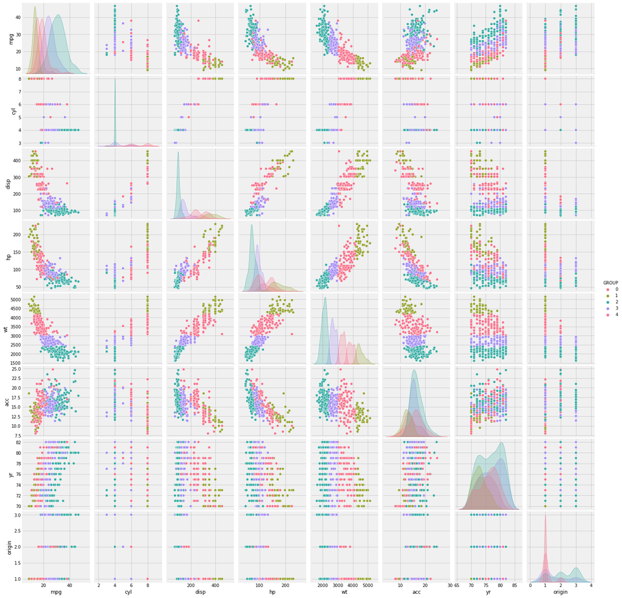

```python
# Pairplot between the features
sns.pairplot(car_details,diag_kind='kde',palette="husl",hue="GROUP")
```

Thus, now we are able to see a clear distinguish between most of the features, based on the group we derived from the optimal elbow point

#### G. Pass a new DataPoint and predict which cluster it belongs to. [2 Marks]

```python
# Creating a synthetic dataframe
datapoints = pd.DataFrame({"mpg": [30, 15, 15], "cyl": [4, 8, 8],"disp": [95, 400, 300],"hp": [70, 180, 130],
                          "wt": [2100, 4500, 3800], "acc": [15, 14, 14],"yr": [75, 75, 75],"origin": [2, 1, 1]})
```

```python
datapoints_predict = final_model_mod.predict(datapoints)
print(datapoints_predict)
```

```
[2 1 4]
```

```python
#Append the prediction as a new feature "GROUP" to datapoint
datapoints["GROUP"] = datapoints_predict
print("Groups Assigned : \n")
datapoints
```

```
Groups Assigned :
```

|  | mpg | cyl | disp | hp | wt | acc | yr | origin | GROUP |
| --- | --- | --- | --- | --- | --- | --- | --- | --- | --- |
| 0 | 30 | 4 | 95 | 70 | 2100 | 15 | 75 | 2 | 2 |
| 1 | 15 | 8 | 400 | 180 | 4500 | 14 | 75 | 1 | 1 |
| 2 | 15 | 8 | 300 | 130 | 3800 | 14 | 75 | 1 | 4 |

```python
## Validation
car_details_clust = car_details.groupby(['GROUP'])
car_details_clust.mean()
```

| GROUP | mpg | cyl | disp | hp | wt | acc | yr | origin |
| --- | --- | --- | --- | --- | --- | --- | --- | --- |
| 0 | 19.704615 | 6.261538 | 239.461538 | 106.292308 | 3300.553846 | 16.238462 | 75.969231 | 1.138462 |
| 1 | 13.551064 | 8.000000 | 369.914894 | 174.595745 | 4504.510638 | 12.787234 | 73.042553 | 1.000000 |
| 2 | 30.989394 | 3.984848 | 97.549242 | 72.439394 | 2098.537879 | 16.605303 | 76.666667 | 2.181818 |
| 3 | 24.647872 | 4.553191 | 147.042553 | 94.446809 | 2706.255319 | 15.652128 | 77.053191 | 1.638298 |
| 4 | 16.029630 | 7.555556 | 306.666667 | 136.981481 | 3880.925926 | 14.305556 | 75.000000 | 1.018519 |

Thus, based on the datapoints results and mean, we could observe that the model is predicting correctly

# Part B - 30 Marks

**• DOMAIN:** Automobile

**• CONTEXT:** The purpose is to classify a given silhouette as one of three types of vehicle, using a set of features extracted from the silhouette. The vehicle may be viewed from one of many different angles.

**• DATA DESCRIPTION:** The data contains features extracted from the silhouette of vehicles in different angles. Four "Corgie" model vehicles were used for the experiment: a double decker bus, Cheverolet van, Saab 9000 and an Opel Manta 400 cars. This particular combination of vehicles was chosen with the expectation that the bus, van and either one of the cars would be readily distinguishable, but it would be more difficult to distinguish between the cars.

• All the features are numeric i.e. geometric features extracted from the silhouette.

**• PROJECT OBJECTIVE:** Apply dimensionality reduction technique – PCA and train a model and compare relative results.

### • STEPS AND TASK [30 Marks]:

### 1. Data Understanding & Cleaning: [5 Marks]

#### A. Read ‘vehicle.csv’ and save as DataFrame. [1 Marks]

```python
vehicle = pd.read_csv('vehicle.csv')
vehicle.head(5)
```

|  | compactness | circularity | distance_circularity | radius_ratio | pr.axis_aspect_ratio | max.length_aspect_ratio | scatter_ratio | elongatedness | pr.axis_rectangularity | max.length_rectangularity | scaled_variance | scaled_variance.1 | scaled_radius_of_gyration | scaled_radius_of_gyration.1 | skewness_about | skewness_about.1 | skewness_about.2 | hollows_ratio | class |
| --- | --- | --- | --- | --- | --- | --- | --- | --- | --- | --- | --- | --- | --- | --- | --- | --- | --- | --- | --- |
| 0 | 95 | 48.0 | 83.0 | 178.0 | 72.0 | 10 | 162.0 | 42.0 | 20.0 | 159 | 176.0 | 379.0 | 184.0 | 70.0 | 6.0 | 16.0 | 187.0 | 197 | van |
| 1 | 91 | 41.0 | 84.0 | 141.0 | 57.0 | 9 | 149.0 | 45.0 | 19.0 | 143 | 170.0 | 330.0 | 158.0 | 72.0 | 9.0 | 14.0 | 189.0 | 199 | van |
| 2 | 104 | 50.0 | 106.0 | 209.0 | 66.0 | 10 | 207.0 | 32.0 | 23.0 | 158 | 223.0 | 635.0 | 220.0 | 73.0 | 14.0 | 9.0 | 188.0 | 196 | car |
| 3 | 93 | 41.0 | 82.0 | 159.0 | 63.0 | 9 | 144.0 | 46.0 | 19.0 | 143 | 160.0 | 309.0 | 127.0 | 63.0 | 6.0 | 10.0 | 199.0 | 207 | van |
| 4 | 85 | 44.0 | 70.0 | 205.0 | 103.0 | 52 | 149.0 | 45.0 | 19.0 | 144 | 241.0 | 325.0 | 188.0 | 127.0 | 9.0 | 11.0 | 180.0 | 183 | bus |

```python
row, column = vehicle.shape
print('The dataset contains', row, 'rows and', column, 'columns')
```

```
The dataset contains 846 rows and 19 columns
```

#### B. Check percentage of missing values and impute with correct approach. [1 Marks]

```python
vehicle.isnull().sum()* 100 / len(vehicle)
```

```
compactness                    0.000000
circularity                    0.591017
distance_circularity           0.472813
radius_ratio                   0.709220
pr.axis_aspect_ratio           0.236407
max.length_aspect_ratio        0.000000
scatter_ratio                  0.118203
elongatedness                  0.118203
pr.axis_rectangularity         0.354610
max.length_rectangularity      0.000000
scaled_variance                0.354610
scaled_variance.1              0.236407
scaled_radius_of_gyration      0.236407
scaled_radius_of_gyration.1    0.472813
skewness_about                 0.709220
skewness_about.1               0.118203
skewness_about.2               0.118203
hollows_ratio                  0.000000
class                          0.000000
dtype: float64
```

```python
for cols in vehicle.columns: # Loop through all columns in the dataframe
    if vehicle[cols].dtype == 'object':
        vehicle[cols] = vehicle[cols].fillna(vehicle[cols].mode())
    if vehicle[cols].dtype != 'object':
        vehicle[cols] = vehicle[cols].fillna(vehicle[cols].median())
```

```python
vehicle.isnull().sum()* 100 / len(vehicle)
```

```
compactness                    0.0
circularity                    0.0
distance_circularity           0.0
radius_ratio                   0.0
pr.axis_aspect_ratio           0.0
max.length_aspect_ratio        0.0
scatter_ratio                  0.0
elongatedness                  0.0
pr.axis_rectangularity         0.0
max.length_rectangularity      0.0
scaled_variance                0.0
scaled_variance.1              0.0
scaled_radius_of_gyration      0.0
scaled_radius_of_gyration.1    0.0
skewness_about                 0.0
skewness_about.1               0.0
skewness_about.2               0.0
hollows_ratio                  0.0
class                          0.0
dtype: float64
```

#### C. Visualize a Pie-chart and print percentage of values for variable ‘class’. [2 Marks]

```python
#Function to plot Pie-Charts for all categorical variables in the dataframe
def pie_charts_for_CategoricalVar(df_pie,m):
    '''Takes in a dataframe(df_pie) and plots pie charts for all categorical columns. m = number of columns required in grid'''

    #get all the column names in the dataframe
    a = []
    for i in df_pie:
        a.append(i)

    #isolate the categorical variable names from a to b
    b = []
    for i in a:
        if (df_pie[i].dtype.name) == 'object':
            b.append(i)

    plt.figure(figsize=(5, 4))
    plt.subplots_adjust(hspace=0.2)

    # number of columns, as inputted while calling the function
    ncols = m
    # calculate number of rows
    nrows = len(b) // ncols + (len(b) % ncols > 0)

    # loop through the length of 'b' and keep track of index
    for n, i in enumerate(b):
        # add a new subplot iteratively using nrows and ncols
        ax = plt.subplot(nrows, ncols, n + 1)

        # filter df and plot 'i' on the new subplot axis
        df_pie.groupby(i).size().plot(kind='pie', autopct='%.2f%%',ax=ax)

        ax.set_title(i.upper())
        ax.set_xlabel("")
        ax.set_ylabel("")
    plt.show()
```

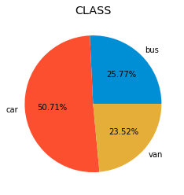

```python
#calling the function to plot pie-charts for categorical variable

pie_charts_for_CategoricalVar(vehicle,1)   #dataframe, no. of cols in the grid
```

#### D. Check for duplicate rows in the data and impute with correct approach. [1 Marks]

```python
vehicle.duplicated().value_counts()
```

```
False    846
dtype: int64
```

There are no True values, which implies there are no duplicate values. Thus, here imputation is not required.

### 2. Data Preparation: [2 Marks]

#### A. Split data into X and Y. [Train and Test optional] [1 Marks]

```python
X = vehicle.drop("class", axis=1)
y = vehicle['class']
```

```python
X_train, X_test, y_train, y_test = train_test_split(X, y, test_size=.20, random_state=1)
```

```python
print("{0:0.2f}% data is in training set".format((len(X_train)/len(vehicle.index)) * 100))
print("{0:0.2f}% data is in test set".format((len(X_test)/len(vehicle.index)) * 100))
```

```
79.91% data is in training set
20.09% data is in test set
```

#### B. Standardize the Data. [1 Marks]

```python
from sklearn.preprocessing import RobustScaler
# Applying RobustScaler to make it less prone to outliers
features = X.columns
scaler = RobustScaler()
X = pd.DataFrame(scaler.fit_transform(X), columns = features)
from scipy.stats import zscore
# Scaling the independent variables
Xs = X.apply(zscore)

display(X.shape, Xs.shape, y.shape)
```

```
(846, 18)
```

```
(846, 18)
```

```
(846,)
```

Normalisation of data is very necessary to apply PCA. Unscaled data can cause problems in the relative comparison of the dataset. For example, if we have a list of numbers under a column in some 2-D dataset, the mean of those numbers is subtracted from all numbers to normalise the 2-D dataset. Normalising the data can be done in a 3-D dataset too. We used RobustScaler to standardise the data

```python
Xs.describe().T
```

|  | count | mean | std | min | 25% | 50% | 75% | max |
| --- | --- | --- | --- | --- | --- | --- | --- | --- |
| compactness | 846.0 | 1.312320e-18 | 1.000592 | -2.512695 | -0.811520 | -0.082445 | 0.768143 | 3.076880 |
| circularity | 846.0 | -8.031401e-17 | 1.000592 | -1.928651 | -0.786846 | -0.134387 | 0.681188 | 2.312338 |
| distance_circularity | 846.0 | 3.884468e-17 | 1.000592 | -2.676060 | -0.769150 | -0.133514 | 1.010632 | 1.900523 |
| radius_ratio | 846.0 | -8.136386e-18 | 1.000592 | -1.943427 | -0.835032 | -0.056160 | 0.782625 | 4.916638 |
| pr.axis_aspect_ratio | 846.0 | -1.465862e-16 | 1.000592 | -1.863187 | -0.593753 | -0.085979 | 0.421794 | 9.688661 |
| max.length_aspect_ratio | 846.0 | -3.543265e-18 | 1.000592 | -1.428157 | -0.340845 | -0.123383 | 0.311542 | 10.097349 |
| scatter_ratio | 846.0 | -9.658678e-17 | 1.000592 | -1.714617 | -0.659704 | -0.358300 | 0.877456 | 2.896861 |
| elongatedness | 846.0 | 7.532719e-17 | 1.000592 | -1.913112 | -1.016511 | 0.264347 | 0.648605 | 2.569893 |
| pr.axis_rectangularity | 846.0 | 2.265065e-16 | 1.000592 | -1.383974 | -0.610886 | -0.224342 | 0.935290 | 3.254554 |
| max.length_rectangularity | 846.0 | 4.671860e-17 | 1.000592 | -2.067876 | -0.758169 | -0.137782 | 0.758332 | 2.757358 |
| scaled_variance | 846.0 | 5.511746e-17 | 1.000592 | -1.869604 | -0.689076 | -0.306201 | 0.906234 | 4.192571 |
| scaled_variance.1 | 846.0 | 3.307047e-17 | 1.000592 | -1.447426 | -0.686337 | -0.429806 | 0.835841 | 3.280679 |
| scaled_radius_of_gyration | 846.0 | 2.178452e-17 | 1.000592 | -2.020069 | -0.790323 | -0.037103 | 0.716116 | 2.868172 |
| scaled_radius_of_gyration.1 | 846.0 | -3.372663e-17 | 1.000592 | -1.801003 | -0.729238 | -0.126370 | 0.342528 | 8.380770 |
| skewness_about | 846.0 | -5.249281e-19 | 1.000592 | -1.298215 | -0.890081 | -0.073812 | 0.538390 | 3.191265 |
| skewness_about.1 | 846.0 | -4.251918e-17 | 1.000592 | -1.411710 | -0.851529 | -0.179311 | 0.716979 | 3.181777 |
| skewness_about.2 | 846.0 | 3.333294e-17 | 1.000592 | -2.101034 | -0.799927 | -0.149374 | 0.663818 | 2.778117 |
| hollows_ratio | 846.0 | 2.887105e-18 | 1.000592 | -1.968200 | -0.723984 | 0.183957 | 0.721997 | 2.067095 |

```python
X_train, X_test, y_train, y_test = train_test_split(Xs, y, test_size=.20, random_state=1)
```

```python
print("{0:0.2f}% data is in training set".format((len(X_train)/len(vehicle.index)) * 100))
print("{0:0.2f}% data is in test set".format((len(X_test)/len(vehicle.index)) * 100))
```

```
79.91% data is in training set
20.09% data is in test set
```

### 3. Model Building: [13 Marks]

#### A. Train a base Classification model using SVM. [1 Marks]

```python
def getAccuracy(testSet, predictions):
	correct = 0
	for x in range(len(testSet)):
		if testSet[x]== predictions[x]:
			correct += 1
	return (correct/float(len(testSet))) * 100.0
```

```python
from sklearn import svm
```

```python
clf = svm.SVC()

clf.fit(X_train , y_train)

y_pred = clf.predict(X_test)
```

```python
y_test = pd.DataFrame(y_test)
y_test_ar = pd.DataFrame.to_numpy(y_test)
```

```python
getAccuracy(y_test_ar,y_pred)
```

```
95.88235294117648
```

#### B. Print Classification metrics for train data. [1 Marks]

```python
print('Accuracy Score of Traning Data: ')
print(clf.score(X_train,y_train))
```

```
Accuracy Score of Traning Data:
0.9807692307692307
```

```python
Precision_svm_bal =precision_score(y_test_ar, y_pred, average='weighted')
print("Precision svm:{0:.4f}".format(Precision_svm_bal))
Recall_svm_bal =recall_score(y_test_ar, y_pred, average='weighted')
print("Recall svm:{0:.4f}".format(Recall_svm_bal))
Accuracy_svm_bal =accuracy_score(y_test_ar, y_pred)
print("Accuracy svm:{0:.4f}".format(Accuracy_svm_bal))
```

```
Precision svm:0.9596
Recall svm:0.9588
Accuracy svm:0.9588
```

```python
print(metrics.classification_report(y_test, y_pred, digits=2))
```

```
              precision    recall  f1-score   support

         bus       0.97      0.97      0.97        37
         car       0.98      0.96      0.97        90
         van       0.91      0.95      0.93        43

    accuracy                           0.96       170
   macro avg       0.95      0.96      0.96       170
weighted avg       0.96      0.96      0.96       170
```

```
Confusion Matrix
```

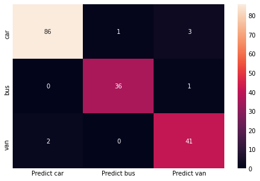

```python
# calculate accuracy measures and confusion matrix
from sklearn import metrics

print("Confusion Matrix")
cm=metrics.confusion_matrix(y_test, y_pred, labels=["car", "bus", "van"])

df_cm = pd.DataFrame(cm, index = [i for i in ["car", "bus", "van"]],
                  columns = [i for i in ["Predict car","Predict bus","Predict van"]])
plt.figure(figsize = (7,5))
sns.heatmap(df_cm, annot=True)
```

#### C. Apply PCA on the data with 10 components. [3 Marks]

```python
from sklearn.decomposition import PCA
```

```python
pca = PCA(n_components=10)
pca.fit(X_train)
```

```
PCA(n_components=10)
```

We need to find the covariance among different dimensions and put them in a covariance matrix. The off-diagonal elements in the covariance matrix will represent the covariance among each pair of variables and the diagonal elements will represent the variances of each variable/dimension.

A covariance matrix constructed for any dataset will always be symmetric. A covariance matrix will represent the relationship in data, and we can understand the amount of variance in each principal component easily.

```python
covMatrix = np.cov(X_train,rowvar=False)
print('CovMatrix: ')
print(covMatrix)
```

```
CovMatrix:
[[ 1.00828811  0.68275041  0.80219903  0.69520251  0.08069097  0.14039109
   0.81978104 -0.78972636  0.82198216  0.67399942  0.76681107  0.82269955
   0.58701043 -0.26149596  0.22654935  0.15525848  0.29780323  0.37261884]
 [ 0.68275041  0.99433133  0.80019199  0.62683151  0.15181599  0.24359025
   0.85060013 -0.82464478  0.84372409  0.94821786  0.80377406  0.8392475
   0.92530286  0.04086474  0.14036876 -0.00778619 -0.09782046  0.05363096]
 [ 0.80219903  0.80019199  1.02180878  0.78639122  0.15645761  0.25960059
   0.92173588 -0.92745666  0.90961762  0.77762277  0.88047241  0.90392127
   0.71908237 -0.2462379   0.11418774  0.27912568  0.16057363  0.35394254]
 [ 0.69520251  0.62683151  0.78639122  1.03295453  0.69809156  0.49117443
   0.74319261 -0.79683068  0.71702135  0.57047169  0.81922248  0.72746776
   0.54410031 -0.16988255  0.04227079  0.17941499  0.38709948  0.49043992]
 [ 0.08069097  0.15181599  0.15645761  0.69809156  1.07886201  0.73912975
   0.09044384 -0.17079859  0.06647968  0.11999459  0.29387323  0.07581205
   0.11946971  0.2027261  -0.06073281 -0.03928505  0.24080727  0.27918479]
 [ 0.14039109  0.24359025  0.25960059  0.49117443  0.73912975  1.1055325
   0.15374714 -0.17091632  0.1462958   0.29316017  0.34565857  0.13065974
   0.17893302  0.355292    0.00387382  0.03724379 -0.01563032  0.15575777]
 [ 0.81978104  0.85060013  0.92173588  0.74319261  0.09044384  0.15374714
   1.01734012 -0.98492197  1.00591306  0.80794728  0.96718691  1.01187102
   0.81306365 -0.0362608   0.06930353  0.2209046   0.00571728  0.12208621]
 [-0.78972636 -0.82464478 -0.92745666 -0.79683068 -0.17079859 -0.17091632
  -0.98492197  1.01075396 -0.96209135 -0.77548286 -0.95086872 -0.96884017
  -0.77771517  0.11384214 -0.04424498 -0.19411122 -0.11623024 -0.22557844]
 [ 0.82198216  0.84372409  0.90961762  0.71702135  0.06647968  0.1462958
   1.00591306 -0.96209135  1.01592711  0.80731451  0.95209729  1.00629221
   0.80786853 -0.02580268  0.0800973   0.22325464 -0.0172357   0.10222086]
 [ 0.67399942  0.94821786  0.77762277  0.57047169  0.11999459  0.29316017
   0.80794728 -0.77548286  0.80731451  0.98053069  0.74883567  0.79443644
   0.8626305   0.02984903  0.12772488  0.00372637 -0.09771743  0.08046679]
 [ 0.76681107  0.80377406  0.88047241  0.81922248  0.29387323  0.34565857
   0.96718691 -0.95086872  0.95209729  0.74883567  1.03424311  0.96666792
   0.79677059  0.13501205  0.03122681  0.19966335  0.01062535  0.08566142]
 [ 0.82269955  0.8392475   0.90392127  0.72746776  0.07581205  0.13065974
   1.01187102 -0.96884017  1.00629221  0.79443644  0.96666792  1.02219173
   0.81020265 -0.02109601  0.07333771  0.20829797  0.0043103   0.10300125]
 [ 0.58701043  0.92530286  0.71908237  0.54410031  0.11946971  0.17893302
   0.81306365 -0.77771517  0.80786853  0.8626305   0.79677059  0.81020265
   1.01218957  0.19253326  0.1693546  -0.06067277 -0.22650429 -0.1228637 ]
 [-0.26149596  0.04086474 -0.2462379  -0.16988255  0.2027261   0.355292
  -0.0362608   0.11384214 -0.02580268  0.02984903  0.13501205 -0.02109601
   0.19253326  1.07452264 -0.08384307 -0.14395621 -0.75655188 -0.82533585]
 [ 0.22654935  0.14036876  0.11418774  0.04227079 -0.06073281  0.00387382
   0.06930353 -0.04424498  0.0800973   0.12772488  0.03122681  0.07333771
   0.1693546  -0.08384307  0.9723723  -0.05972361  0.10923522  0.08813704]
 [ 0.15525848 -0.00778619  0.27912568  0.17941499 -0.03928505  0.03724379
   0.2209046  -0.19411122  0.22325464  0.00372637  0.19966335  0.20829797
  -0.06067277 -0.14395621 -0.05972361  1.02754618  0.08612574  0.21623806]
 [ 0.29780323 -0.09782046  0.16057363  0.38709948  0.24080727 -0.01563032
   0.00571728 -0.11623024 -0.0172357  -0.09771743  0.01062535  0.0043103
  -0.22650429 -0.75655188  0.10923522  0.08612574  0.98898507  0.89759745]
 [ 0.37261884  0.05363096  0.35394254  0.49043992  0.27918479  0.15575777
   0.12208621 -0.22557844  0.10222086  0.08046679  0.08566142  0.10300125
  -0.1228637  -0.82533585  0.08813704  0.21623806  0.89759745  1.02292064]]
```

We have to find the eigenvalues of the covariance matrix which represents the variability in data on an orthogonal basis in the plot. We will also have to find eigenvectors of the covariance matrix which will represent the direction in which maximum variance among the data occurs.

```python
print("The Eigen Values are: ")
print(pca.explained_variance_)
```

```
The Eigen Values are:
[9.50089775 3.06174692 2.14472676 1.20347857 0.88977284 0.54115703
 0.37164653 0.22067912 0.1653225  0.08820429]
```

```python
print("The Eigen Vectors are: ")
print(pca.components_)
```

```
The Eigen Vectors are:
[[ 0.2737973   0.28995779  0.30675678  0.26992016  0.08057258  0.09698893
   0.31755253 -0.31397169  0.31413683  0.27807969  0.31206767  0.31479695
   0.27155959 -0.02238039  0.03852228  0.06002525  0.03157095  0.07657319]
 [-0.12459742  0.12123705 -0.07894085 -0.18483581 -0.11114943  0.01641307
   0.04954787  0.01138039  0.06011204  0.11183328  0.07070474  0.05683969
   0.21150495  0.50008714 -0.04635922 -0.13121688 -0.53121007 -0.54171054]
 [-0.10936572 -0.02989205 -0.05514196  0.27212206  0.6340212   0.60183557
  -0.09963711  0.06181951 -0.11105143 -0.0248677   0.06463404 -0.10978392
  -0.03893184  0.29199803 -0.09199702 -0.06798063  0.02144846  0.05110894]
 [ 0.08350587  0.18623738 -0.06576862 -0.0350453   0.03608396  0.01018591
  -0.09194092  0.07555472 -0.08975464  0.18210319 -0.11771348 -0.08719303
   0.20214727 -0.07859534  0.56228103 -0.70423051  0.11306726  0.05117802]
 [ 0.08000297 -0.07398863  0.04421627 -0.05813457 -0.05924743  0.20184318
  -0.01855969  0.08461031  0.0013652  -0.05274451 -0.0061632  -0.02047981
  -0.04898491  0.13845968  0.76682799  0.5570854  -0.08486349 -0.02555825]
 [ 0.15108724 -0.31784454 -0.13777926  0.24431333  0.22267631 -0.41518969
   0.11755609 -0.13210076  0.10547051 -0.46625767  0.24082551  0.1644983
  -0.14268225  0.24411596  0.19249313 -0.18766765  0.16952919 -0.22292941]
 [ 0.4708803  -0.23580557  0.05369867 -0.1877617  -0.41269182  0.49392505
   0.06175585  0.02473267  0.09431655 -0.08225047  0.10535622  0.08333302
  -0.36460162  0.11843217 -0.09788819 -0.27172224  0.03259155  0.02616497]
 [ 0.58040019  0.19683612 -0.41095942 -0.07618659  0.10506682 -0.19818075
  -0.10799777  0.22706051 -0.07208077  0.26532964 -0.07739877 -0.05605168
   0.1015031   0.31109785 -0.15285264  0.21864004  0.27000835  0.01673321]
 [-0.44365591  0.01213621 -0.17702086 -0.24441931 -0.27296472  0.12034586
   0.03861225 -0.15131849 -0.01745805 -0.02658046  0.2865458   0.07011617
   0.24040533  0.34285634  0.00929068  0.02392159  0.55150221  0.17426813]
 [-0.25600469  0.12000684 -0.2286499  -0.03594475  0.10614331 -0.10709109
   0.16732604 -0.17030953  0.19005342  0.45424107 -0.13172794  0.15432478
  -0.68921742  0.11127404  0.10638422 -0.03527723  0.0097906   0.05536033]]
```

And the percentage of variation explained by each eigen Vector

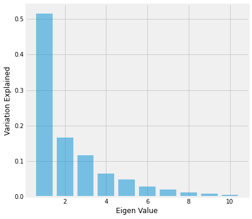

```python
plt.rcParams["figure.figsize"] = (6,6)
plt.bar(list(range(1,11)),pca.explained_variance_ratio_,alpha=0.5, align='center')
plt.ylabel('Variation Explained')
plt.xlabel('Eigen Value')
plt.show()
```

#### D. Visualize Cumulative Variance Explained with Number of Components. [2 Marks]

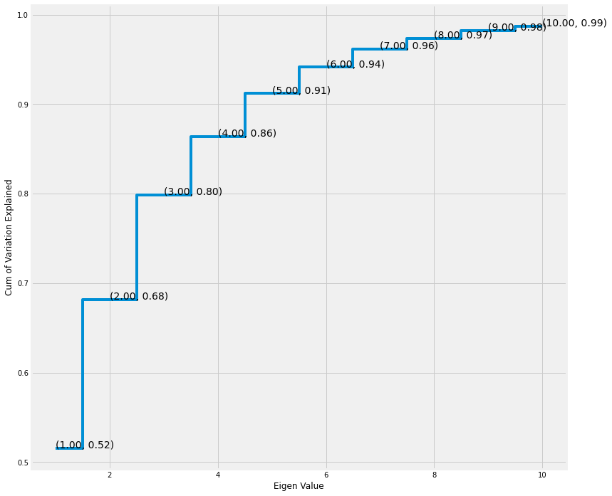

```python
plt.rcParams["figure.figsize"] = (12,12)
plt.step(list(range(1,11)),np.cumsum(pca.explained_variance_ratio_), where='mid')
for xy in zip(list(range(1,11)),np.cumsum(pca.explained_variance_ratio_)):
    plt.annotate('(%.2f, %.2f)' % xy, xy=xy, fontsize=14)
plt.ylabel('Cum of Variation Explained')
plt.xlabel('Eigen Value')
plt.show()
```

#### E. Draw a horizontal line on the above plot to highlight the threshold of 90%. [1 Marks]

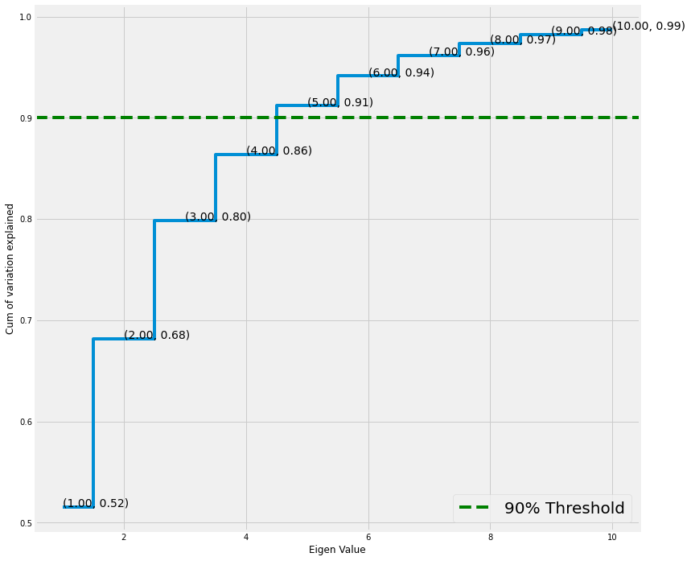

```python
Threshold = 0.9
plt.step(list(range(1,11)),np.cumsum(pca.explained_variance_ratio_), where='mid')
for xy in zip(list(range(1,11)),np.cumsum(pca.explained_variance_ratio_)):
    plt.annotate('(%.2f, %.2f)' % xy, xy=xy, fontsize=14)
plt.ylabel('Cum of variation explained')
plt.xlabel('Eigen Value')
plt.axhline(Threshold, color = 'g', linestyle = '--', label = '90% Threshold')
plt.legend(loc ="lower right", fontsize=20); plt.show()
```

#### F. Apply PCA on the data. This time Select Minimum Components with 90% or above variance explained. [2 Marks]

Minimum component with 90% or above variance is 5. So, choosing that component

```python
pca = PCA(n_components=5)
pca.fit(X_train)
```

```
PCA(n_components=5)
```

```python
print("The Eigen Values")
print(pca.explained_variance_)
```

```
The Eigen Values
[9.50089775 3.06174692 2.14472676 1.20347857 0.88977284]
```

```python
print("The Eigen Vectors")
print(pca.components_)
```

```
The Eigen Vectors
[[ 0.2737973   0.28995779  0.30675678  0.26992016  0.08057258  0.09698893
   0.31755253 -0.31397169  0.31413683  0.27807969  0.31206767  0.31479695
   0.27155959 -0.02238039  0.03852228  0.06002525  0.03157095  0.07657319]
 [-0.12459742  0.12123705 -0.07894085 -0.18483581 -0.11114943  0.01641307
   0.04954787  0.01138039  0.06011204  0.11183328  0.07070474  0.05683969
   0.21150495  0.50008714 -0.04635922 -0.13121688 -0.53121007 -0.54171054]
 [-0.10936572 -0.02989205 -0.05514196  0.27212206  0.6340212   0.60183557
  -0.09963711  0.06181951 -0.11105143 -0.0248677   0.06463404 -0.10978392
  -0.03893184  0.29199803 -0.09199702 -0.06798063  0.02144846  0.05110894]
 [ 0.08350587  0.18623738 -0.06576862 -0.0350453   0.03608396  0.01018591
  -0.09194092  0.07555472 -0.08975464  0.18210319 -0.11771348 -0.08719303
   0.20214727 -0.07859534  0.56228103 -0.70423051  0.11306726  0.05117802]
 [ 0.08000297 -0.07398863  0.04421627 -0.05813457 -0.05924743  0.20184318
  -0.01855969  0.08461031  0.0013652  -0.05274451 -0.0061632  -0.02047981
  -0.04898491  0.13845968  0.76682799  0.5570854  -0.08486349 -0.02555825]]
```

```python
# Applying PCA on Data
X_t_train = pca.transform(X_train)
X_t_test = pca.transform(X_test)
```

#### G. Train SVM model on components selected from above step. [1 Marks]

```python
clf = svm.SVC()
clf.fit(X_train, y_train)
print ('Before PCA score', clf.score(X_test, y_test))

clf.fit(X_t_train, y_train)
print ('After PCA score', clf.score(X_t_test, y_test))
```

```
Before PCA score 0.9588235294117647
After PCA score 0.7705882352941177
```

```python
y_pred = clf.predict(X_t_test)
```

```python
def getAccuracy(testSet, predictions):
	correct = 0
	for x in range(len(testSet)):
		if testSet[x]== predictions[x]:
			correct += 1
	return (correct/float(len(testSet))) * 100.0
```

```python
y_test = pd.DataFrame(y_test)
y_test_ar = pd.DataFrame.to_numpy(y_test)
```

```python
getAccuracy(y_test_ar,y_pred)
```

```
77.05882352941177
```

In the given dataset we trained models with the orginal and dimensionally reduced datsets. The effects of PCA can be clearly appreciated on a fairly large datsaset.

#### H. Print Classification metrics for train data of above model and share insights. [2 Marks]

```python
print('Accuracy Score of Traning Data: ')
print(clf.score(X_t_train,y_train))
```

```
Accuracy Score of Traning Data:
0.7988165680473372
```

```python
Precision_svm_bal =precision_score(y_test_ar, y_pred, average='weighted')
print("Precision svm:{0:.4f}".format(Precision_svm_bal))
Recall_svm_bal =recall_score(y_test_ar, y_pred, average='weighted')
print("Recall svm:{0:.4f}".format(Recall_svm_bal))
Accuracy_svm_bal =accuracy_score(y_test_ar, y_pred)
print("Accuracy svm:{0:.4f}".format(Accuracy_svm_bal))
```

```
Precision svm:0.7863
Recall svm:0.7706
Accuracy svm:0.7706
```

```python
print(metrics.classification_report(y_test, y_pred, digits=2))
```

```
              precision    recall  f1-score   support

         bus       0.86      0.65      0.74        37
         car       0.84      0.82      0.83        90
         van       0.61      0.77      0.68        43

    accuracy                           0.77       170
   macro avg       0.77      0.75      0.75       170
weighted avg       0.79      0.77      0.77       170
```

```
Confusion Matrix
```

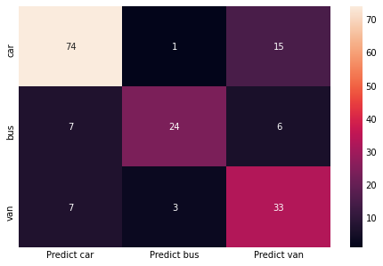

```python
# calculate accuracy measures and confusion matrix
from sklearn import metrics

print("Confusion Matrix")
cm=metrics.confusion_matrix(y_test, y_pred, labels=["car", "bus", "van"])

df_cm = pd.DataFrame(cm, index = [i for i in ["car", "bus", "van"]],
                  columns = [i for i in ["Predict car","Predict bus","Predict van"]])
plt.figure(figsize = (7,5))
sns.heatmap(df_cm, annot=True)
```

From the above metrics we could observe that the train data accuracy is 0.79 and test data accuracy is 0.77, which implies there is no overfitting or underfitting. But, we need to tune the parameters to improve performance. In the given dataset we trained models with the orginal and dimensionally reduced datsets. The effects of PCA can be clearly appreciated on a fairly large datsaset.

### 4. Performance Improvement: [5 Marks]

#### A. Train another SVM on the components out of PCA. Tune the parameters to improve performance. [2 Marks]

```python
from sklearn.model_selection import GridSearchCV
from sklearn.datasets import make_classification
from sklearn.ensemble import RandomForestClassifier
```

```python
#Create a dictionary of possible parameters
params_grid = {'C': [0.001, 0.01, 0.1, 1, 10, 100],
          'gamma': [0.0001, 0.001, 0.01, 0.1, 0.5],
          'kernel':['linear','rbf'] }

X_t_train = pca.transform(X_train)
X_t_test = pca.transform(X_test)

#Create the GridSearchCV object
grid_clf = GridSearchCV(svm.SVC(class_weight='balanced'), params_grid)

#Fit the data with the best possible parameters
grid_clf = grid_clf.fit(X_t_train, y_train)

#Print the best estimator with it's parameters
grid_clf.best_estimator_
```

```
SVC(C=10, class_weight='balanced', gamma=0.1)
```

```python
clf = grid_clf.best_estimator_
clf.fit(X_t_train , y_train)

y_pred_svm = clf.predict(X_t_test)

getAccuracy(y_test_ar , y_pred_svm)
```

```
81.76470588235294
```

#### B. Share best Parameters observed from above step. [1 Marks]

```python
#Print the best estimator with it's parameters
grid_clf.best_estimator_
```

```
SVC(C=10, class_weight='balanced', gamma=0.1)
```

#### C. Print Classification metrics for train data of above model and share relative improvement in performance in all the models along with insights. [2 Marks]

```python
print('Accuracy Score of Traning Data: ')
print(clf.score(X_t_train,y_train))
```

```
Accuracy Score of Traning Data:
0.8742603550295858
```

```python
Precision_svm_bal =precision_score(y_test_ar, y_pred_svm, average='weighted')
print("Precision svm after balancing:{0:.4f}".format(Precision_svm_bal))
Recall_svm_bal =recall_score(y_test_ar, y_pred_svm, average='weighted')
print("Recall svm after balancing:{0:.4f}".format(Recall_svm_bal))
Accuracy_svm_bal =accuracy_score(y_test_ar, y_pred_svm)
print("Accuracy svm after balancing:{0:.4f}".format(Accuracy_svm_bal))
```

```
Precision svm after balancing:0.8371
Recall svm after balancing:0.8176
Accuracy svm after balancing:0.8176
```

```python
print(metrics.classification_report(y_test, y_pred_svm, digits=2))
```

```
              precision    recall  f1-score   support

         bus       0.86      0.81      0.83        37
         car       0.91      0.79      0.85        90
         van       0.67      0.88      0.76        43

    accuracy                           0.82       170
   macro avg       0.81      0.83      0.81       170
weighted avg       0.84      0.82      0.82       170
```

```
Confusion Matrix
```

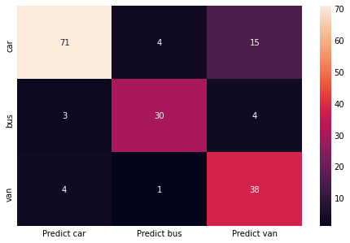

```python
# calculate accuracy measures and confusion matrix
from sklearn import metrics

print("Confusion Matrix")
cm=metrics.confusion_matrix(y_test, y_pred_svm, labels=["car", "bus", "van"])

df_cm = pd.DataFrame(cm, index = [i for i in ["car", "bus", "van"]],
                  columns = [i for i in ["Predict car","Predict bus","Predict van"]])
plt.figure(figsize = (7,5))
sns.heatmap(df_cm, annot=True)
```

After doing hyperparameter tuning, we have obtained the best parameters SVC(C=10, class_weight='balanced', gamma=0.1) for the SVM model. And, the train data accuracy increased from 0.79 to 0.87. Similarly, there is an increase in accuracy from 0.77 to 0.82 for the test data. In the given dataset we trained models with the orginal and dimensionally reduced datsets. The effects of PCA can be clearly appreciated on a fairly large datsaset.

### 5. Data Understanding & Cleaning: [5 Marks]

#### A. Explain pre-requisite/assumptions of PCA. [2 Marks]

### Principal Component Analysis

PCA is an unsupervised statistical technique that is used to reduce the dimensions of the dataset. ML models with many input variables or higher dimensionality tend to fail when operating on a higher input dataset. PCA helps in identifying relationships among different variables & then coupling them. PCA works on some assumptions which are to be followed and it helps developers maintain a standard.

PCA involves the transformation of variables in the dataset into a new set of variables which are called PCs (Principal Components). The principal components would be equal to the number of original variables in the given dataset.

### Pre-requisite for Applying PCA

In our case we have about 846 rows and 19 columns, which implies there are 18 independant variables. Thus, there are so many redundant features and combining these features will help to extract the important informations out of the dataset. Also, the visualization of these features in the dataset is also limited. Thus, PCA helps to reduce the dimensionality and help us to get better insight of the datasets.

We need to find out the correlation among the features (correlated variables). Finding correlation manually in all the features is nearly impossible, frustrating and time-consuming. PCA does this for us efficiently.

With so many features, the performance of the algorithm will drastically degrade. PCA is a very common way to speed up the Machine Learning algorithm by getting rid of correlated variables which don’t contribute in any decision making. The training time of the algorithms reduces significantly with less number of features.

Overfitting mainly occurs when there are too many variables in the dataset. So, PCA helps in overcoming the overfitting issue by reducing the number of features.

• Normalisation of data is very necessary to apply PCA. Unscaled data can cause problems in the relative comparison of the dataset. For example, if we have a list of numbers under a column in some 2-D dataset, the mean of those numbers is subtracted from all numbers to normalise the 2-D dataset. Normalising the data can be done in a 3-D dataset too. We used RobustScaler to standardise the data

• Once you have normalised the dataset, find the covariance among different dimensions and put them in a covariance matrix. The off-diagonal elements in the covariance matrix will represent the covariance among each pair of variables and the diagonal elements will represent the variances of each variable/dimension.

A covariance matrix constructed for any dataset will always be symmetric. A covariance matrix will represent the relationship in data, and we can understand the amount of variance in each principal component easily.

• We have to find the eigenvalues of the covariance matrix which represents the variability in data on an orthogonal basis in the plot. We will also have to find eigenvectors of the covariance matrix which will represent the direction in which maximum variance among the data occurs.

Suppose the covariance matrix ‘C’ has a square matrix ‘E’ of eigenvalues of ‘C’. In that case, it should satisfy this equation – determinant of (EI – C) = 0, where ‘I’ is an identity matrix of the same dimension as of ‘C’. We should check that the covariance matrix is a symmetric/square matrix because then only the calculation of eigenvalues is possible.

• Arrange the eigenvalues in an ascending/descending order and select the higher eigenvalues. We can choose how many eigenvalues we want to proceed with. We will lose some information while ignoring the smaller eigenvalues, but those minute values will not create enough impact on the final result.

The selected higher eigenvalues will become the dimensions of our updated feature set. We also form a feature vector, which is a vector matrix consisting of eigenvectors of relative chosen eigenvalues.

• Using the feature vector, we find the principal components of the dataset under analysis. We multiply the transpose of the feature vector with the transpose of the scaled matrix (a scaled version of data after normalisation) to obtain a matrix containing principal components.

We will notice that the highest eigenvalue will be appropriate for the data, and the other ones will not provide much information about the dataset. This proves that we are not losing data when reducing the dimensions of the dataset; we are just representing it more effectively.

These methods are implemented to finally reduce the dimensions of any dataset in PCA.

### Assumptions in PCA

There are some assumptions in PCA which are to be followed as they will lead to accurate functioning of this dimensionality reduction technique in ML. The assumptions in PCA are:

• There must be **linearity in the data set**, i.e. the variables combine in a linear manner to form the dataset. The variables exhibit relationships among themselves.

• PCA assumes that the principal component with **high variance must be paid attention and the PCs with lower variance are disregarded as noise**. Pearson correlation coefficient framework led to the origin of PCA, and there it was assumed first that the axes with high variance would only be turned into principal components.

• All variables should be accessed on the **same ratio level of measurement**. The most preferred norm is at least 150 observations of the sample set with a ratio measurement of 5:1.

• Extreme values that deviate from other data points in any dataset, which are also called **outliers, should be less**. More number of outliers will represent experimental errors and will degrade the ML model/algorithm.

• The feature set must be **correlated** and the reduced feature set after applying PCA will represent the original data set but in an effective way with fewer dimensions.

In a nut-shell,

1.Independent variables are highly correlated to each other.

2.Variables included are metric level or nominal level.

3.Features are low dimensional in nature.

4.Independent variables are numeric in nature.

H0: Variables are uncorrelated.

H1: Variables are correlated.

#### B. Explain advantages and limitations of PCA. [3 Marks]

### Advantages of principal component analysis

Principal component analysis (PCA) is a statistical method used to transform a large number of possibly correlated variables into a much smaller number of uncorrelated variables referred to as principal components. PCA can be used as a data reduction technique as it allows us to find the most important variables that are needed to describe a dataset. PCA can also be used to reduce the dimensionality of the data space in order to get insight on the inner structure of the data. This is helpful when dealing with large datasets.

**1. Removes Correlated Features:**

In a real-world scenario, this is very common that we get thousands of features in the dataset. We cannot run the algorithm on all the features as it will reduce the performance of the algorithm and it will not be easy to visualize that many features in any kind of graph. So, we MUST reduce the number of features in the dataset.

We need to find out the correlation among the features (correlated variables). Finding correlation manually in thousands of features is nearly impossible, frustrating and time-consuming. PCA does this for us efficiently.

**2. Improves Algorithm Performance:**

With so many features, the performance of the algorithm will drastically degrade. PCA is a very common way to speed up the Machine Learning algorithm by getting rid of correlated variables which don’t contribute in any decision making. The training time of the algorithms reduces significantly with less number of features.

So, if the input dimensions are too high, then using PCA to speed up the algorithm is a reasonable choice.

**3. Reduces Overfitting:**

Overfitting mainly occurs when there are too many variables in the dataset. So, PCA helps in overcoming the overfitting issue by reducing the number of features.

**4. Improves Visualization:**

It is very hard to visualize and understand the data in high dimensions. PCA transforms a high dimensional data to low dimensional data (2 dimension) so that it can be visualized easily.

We can use 2D Scree Plot to see which Principal Components result in high variance and have more impact as compared to other Principal Components.

### Limitations of Principal Component Analysis

PCA is a great tool to analyze your data and extract two or three most important factors. It is great to spot the outliers and the trend. But, it has some limitations like: It is not suitable for small data sets (Generally, data set should have more than 30 rows). It does not find the important factors but selects them based on the values. So, it is difficult to find the important factors. It does not have a strong mathematical structure behind it. It is difficult to compare the data with PCA. It cannot find any non-linear relationships.

**1. Independent variables become less interpretable:**

After implementing PCA on the dataset, your original features will turn into Principal Components. Principal Components are the linear combination of your original features. Principal Components are not as readable and interpretable as original features.

**2. Data standardization is must before PCA:**

You must standardize your data before implementing PCA, otherwise PCA will not be able to find the optimal Principal Components.

For instance, if a feature set has data expressed in units of Kilograms, Light years, or Millions, the variance scale is huge in the training set. If PCA is applied on such a feature set, the resultant loadings for features with high variance will also be large. Hence, principal components will be biased towards features with high variance, leading to false results.

Also, for standardization, all the categorical features are required to be converted into numerical features before PCA can be applied.

PCA is affected by scale, so you need to scale the features in your data before applying PCA. Use StandardScaler from Scikit Learn to standardize the dataset features onto unit scale (mean = 0 and standard deviation = 1) which is a requirement for the optimal performance of many Machine Learning algorithms.

**3. Information Loss:**

Although Principal Components try to cover maximum variance among the features in a dataset, if we don’t select the number of Principal Components with care, it may miss some information as compared to the original list of features.

#### How to resolve PCA Disadvantages

Standard PCA **struggles with Big Data** when we need out-of-core (when data is too big to fit in RAM) computation.

Also, standard PCA can detect **only linear relationships** between variables/features. What if relationships are non-linear?

If I have many features in my dataset (say 400000), & I have a rough idea that the dataset has ~400 features that would be useful (others are just noise or 0s or anything else; not knowing which features), is there a way I can shortlist these 400 features before applying PCA to **save computation?**

Sometimes, the transformed data we generate after applying PCA should **ideally be sparse** (why? requires some explanation, will be discussing this later in the post) but standard PCA always generates dense expressions.

#### Incremental PCA

Incremental PCA helps us to resolve our 1st problem i.e PCA over big data where entire data can’t be accommodated in memory at once.

It follows the ideology of Incremental learning by running multiple SVD decomposition on multiple batches (say m batches made out of dataset) comprising of ’n’ samples to get to the final Principal Components. These batches are loaded in the memory using memory-mapped files generated using np.memmap(). Hence, a batch of data can be accessed without loading entire data in memory

#### Kernel PCA

As mentioned earlier, standard PCA is able to depict only linear relationships & hence, correct dimension reduction is possible if data has only linear relations.

But when the relationship between different features in the dataset are non-linear, kernel PCA can be used.

It applies a transformation function (can be RBF, polynomial, Gaussian, etc; similar to kernels in SVM) & then all the steps are similar to standard PCA.

#### Randomized/Approximate PCA

Rank of a matrix determines non-zero eigenvalues of the matrix

So, when we transform our original data using low-rank approximation, we are rejecting unimportant Eigenvalues & hence eliminating the least important Principal Components automatically.

Now, if earlier, it was possible to get say ’n’ eigenvalues, we might be able to get ‘m’ eigenvalues for the transformed dataset where m < n hence reduction in computation. Rest other steps remain the same as standard PCA

#### Sparse PCA

Sparse principal component analysis (sparse PCA) is a specialised technique used in statistical analysis and, in particular, in the analysis of multivariate data sets. It extends the classic method of principal component analysis (PCA) for the reduction of dimensionality of data by introducing sparsity structures to the input variables.

Sparse PCA aims at extracting sparse eigenvectors that best represent the data.

A particular disadvantage of ordinary PCA is that the principal components are usually linear combinations of all input variables. Sparse PCA overcomes this disadvantage by finding linear combinations that contain just a few input variables.

### Applications of PCA

Data is generated in many sectors, and there is a need to analyse data for the growth of any firm/company. PCA will help in reducing the dimensions of the data, thus making it easier to analyse. The applications of PCA are:

• Neuroscience – Neuroscientists use PCA to identify any neuron or to map the brain structure during phase transitions.

• Finance – PCA is used in the finance sector for reducing the dimensionality of data to create fixed income portfolios. Many other facets of the finance sector involve PCA like forecasting returns, making asset allocation algorithms or equity algorithms, etc.

• Image Technology – PCA is also used for image compression or digital image processing. Each image can be represented via a matrix by plotting the intensity values of each pixel, and then we can apply PCA on it.

• Facial Recognition – PCA in facial recognition leads to the creation of eigenfaces which makes facial recognition more accurate.

• Medical – PCA is used on a lot of medical data to find the correlation among different variables. For example, doctors use PCA to show the correlation between cholesterol & low-density lipoprotein.

• Security – Anomalies can be found easily using PCA. It is used to identify cyber/computer attacks and visualise them with the help of PCA.